# Risk Factor Analysis

## Outcome Variable

**Outcome Variable:** whz

## Predictor Variables

**Intervention Variable:** feducyrs

**Adjustment Set:**

- arm
- W_mage
- meducyrs
- hhwealth_quart
- W_mhtcm
- W_mwtkg
- W_mbmi
- W_gagebrth
- W_birthwt
- W_birthlen
- single
- delta_W_mage
- delta_meducyrs
- delta_hhwealth_quart
- delta_W_mhtcm
- delta_W_mwtkg
- delta_W_mbmi
- delta_W_gagebrth
- delta_W_birthwt
- delta_W_birthlen
- delta_single

## Stratifying Variables

The analysis was stratified on these variable(s):

- agecat
- studyid
- country

## Data Summary

| agecat | studyid | country | feducyrs | n_cell | n |
| --- | --- | --- | --- | --- | --- |
| Birth | COHORTS | GUATEMALA | High | 136 | 718 |
| Birth | COHORTS | GUATEMALA | Low | 311 | 718 |
| Birth | COHORTS | GUATEMALA | Medium | 271 | 718 |
| Birth | COHORTS | INDIA | High | 507 | 1291 |
| Birth | COHORTS | INDIA | Low | 414 | 1291 |
| Birth | COHORTS | INDIA | Medium | 370 | 1291 |
| Birth | COHORTS | PHILIPPINES | High | 994 | 2728 |
| Birth | COHORTS | PHILIPPINES | Low | 773 | 2728 |
| Birth | COHORTS | PHILIPPINES | Medium | 961 | 2728 |
| Birth | GMS-Nepal | NEPAL | High | 162 | 640 |
| Birth | GMS-Nepal | NEPAL | Low | 266 | 640 |
| Birth | GMS-Nepal | NEPAL | Medium | 212 | 640 |
| Birth | JiVitA-3 | BANGLADESH | High | 4049 | 17367 |
| Birth | JiVitA-3 | BANGLADESH | Low | 7452 | 17367 |
| Birth | JiVitA-3 | BANGLADESH | Medium | 5866 | 17367 |
| Birth | JiVitA-4 | BANGLADESH | High | 510 | 2323 |
| Birth | JiVitA-4 | BANGLADESH | Low | 913 | 2323 |
| Birth | JiVitA-4 | BANGLADESH | Medium | 900 | 2323 |
| Birth | MAL-ED | BANGLADESH | High | 44 | 119 |
| Birth | MAL-ED | BANGLADESH | Low | 33 | 119 |
| Birth | MAL-ED | BANGLADESH | Medium | 42 | 119 |
| Birth | MAL-ED | INDIA | High | 7 | 23 |
| Birth | MAL-ED | INDIA | Low | 13 | 23 |
| Birth | MAL-ED | INDIA | Medium | 3 | 23 |
| Birth | MAL-ED | NEPAL | High | 3 | 9 |
| Birth | MAL-ED | NEPAL | Low | 3 | 9 |
| Birth | MAL-ED | NEPAL | Medium | 3 | 9 |
| Birth | MAL-ED | PERU | High | 84 | 190 |
| Birth | MAL-ED | PERU | Low | 56 | 190 |
| Birth | MAL-ED | PERU | Medium | 50 | 190 |

[output cut: 135 more lines]

The following strata were considered:

- agecat: 24 months, studyid: COHORTS, country: GUATEMALA
- agecat: 24 months, studyid: COHORTS, country: INDIA
- agecat: 24 months, studyid: COHORTS, country: PHILIPPINES
- agecat: 24 months, studyid: GMS-Nepal, country: NEPAL
- agecat: 24 months, studyid: JiVitA-3, country: BANGLADESH
- agecat: 24 months, studyid: JiVitA-4, country: BANGLADESH
- agecat: 24 months, studyid: LCNI-5, country: MALAWI
- agecat: 24 months, studyid: MAL-ED, country: BANGLADESH
- agecat: 24 months, studyid: MAL-ED, country: INDIA
- agecat: 24 months, studyid: MAL-ED, country: NEPAL
- agecat: 24 months, studyid: MAL-ED, country: PERU
- agecat: 24 months, studyid: MAL-ED, country: SOUTH AFRICA
- agecat: 24 months, studyid: MAL-ED, country: TANZANIA, UNITED REPUBLIC OF
- agecat: 24 months, studyid: NIH-Crypto, country: BANGLADESH
- agecat: 24 months, studyid: PROBIT, country: BELARUS
- agecat: 24 months, studyid: PROVIDE, country: BANGLADESH
- agecat: 24 months, studyid: TanzaniaChild2, country: TANZANIA, UNITED REPUBLIC OF
- agecat: 24 months, studyid: ZVITAMBO, country: ZIMBABWE
- agecat: 6 months, studyid: COHORTS, country: GUATEMALA
- agecat: 6 months, studyid: COHORTS, country: INDIA
- agecat: 6 months, studyid: COHORTS, country: PHILIPPINES
- agecat: 6 months, studyid: GMS-Nepal, country: NEPAL
- agecat: 6 months, studyid: JiVitA-3, country: BANGLADESH
- agecat: 6 months, studyid: JiVitA-4, country: BANGLADESH
- agecat: 6 months, studyid: LCNI-5, country: MALAWI
- agecat: 6 months, studyid: MAL-ED, country: BANGLADESH
- agecat: 6 months, studyid: MAL-ED, country: INDIA
- agecat: 6 months, studyid: MAL-ED, country: NEPAL
- agecat: 6 months, studyid: MAL-ED, country: PERU
- agecat: 6 months, studyid: MAL-ED, country: SOUTH AFRICA
- agecat: 6 months, studyid: MAL-ED, country: TANZANIA, UNITED REPUBLIC OF
- agecat: 6 months, studyid: NIH-Crypto, country: BANGLADESH
- agecat: 6 months, studyid: PROBIT, country: BELARUS
- agecat: 6 months, studyid: PROVIDE, country: BANGLADESH
- agecat: 6 months, studyid: SAS-CompFeed, country: INDIA
- agecat: 6 months, studyid: SAS-FoodSuppl, country: INDIA
- agecat: 6 months, studyid: TanzaniaChild2, country: TANZANIA, UNITED REPUBLIC OF
- agecat: 6 months, studyid: ZVITAMBO, country: ZIMBABWE
- agecat: Birth, studyid: COHORTS, country: GUATEMALA
- agecat: Birth, studyid: COHORTS, country: INDIA
- agecat: Birth, studyid: COHORTS, country: PHILIPPINES
- agecat: Birth, studyid: GMS-Nepal, country: NEPAL
- agecat: Birth, studyid: JiVitA-3, country: BANGLADESH
- agecat: Birth, studyid: JiVitA-4, country: BANGLADESH
- agecat: Birth, studyid: MAL-ED, country: BANGLADESH
- agecat: Birth, studyid: MAL-ED, country: INDIA
- agecat: Birth, studyid: MAL-ED, country: NEPAL
- agecat: Birth, studyid: MAL-ED, country: PERU
- agecat: Birth, studyid: MAL-ED, country: SOUTH AFRICA
- agecat: Birth, studyid: MAL-ED, country: TANZANIA, UNITED REPUBLIC OF
- agecat: Birth, studyid: NIH-Crypto, country: BANGLADESH
- agecat: Birth, studyid: PROBIT, country: BELARUS
- agecat: Birth, studyid: PROVIDE, country: BANGLADESH
- agecat: Birth, studyid: SAS-CompFeed, country: INDIA
- agecat: Birth, studyid: ZVITAMBO, country: ZIMBABWE

### Dropped Strata

Some strata were dropped due to rare outcomes:

- agecat: Birth, studyid: MAL-ED, country: INDIA
- agecat: Birth, studyid: MAL-ED, country: NEPAL
- agecat: 24 months, studyid: TanzaniaChild2, country: TANZANIA, UNITED REPUBLIC OF

## Methods Detail

We’re interested in the causal parameters $E[Y_a]$ for all values of $a \in \mathcal{A}$. These parameters represent the mean outcome if, possibly contrary to fact, we intervened to set all units to have $A=a$. Under the randomization and positivity assumptions, these are identified by the statistical parameters $\psi_a=E_W[E_{Y|A,W}(Y|A=a,W)]$. In addition, we’re interested in the mean of $Y$, $E[Y]$ under no intervention (the observed mean). We will estimate these parameters by using SuperLearner to fit the relevant likelihood factors – $E_{Y|A,W}(Y|A=a,W)$ and $p(A=a|W)$, and then updating our likelihood fit using a joint TMLE.

For unadjusted analyses ($W=\{\}$), initial likelihoods were estimated using Lrnr_glm to estimate the simple $E(Y|A)$ and Lrnr_mean to estimate $p(A)$. For adjusted analyses, a small library containing Lrnr_glmnet, Lrnr_xgboost, and Lrnr_mean was used.

Having estimated these parameters, we will then use the delta method to estimate relative risks and attributable risks relative to a prespecified baseline level of $A$.

# Results Detail

## Results Plots

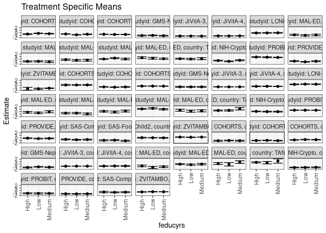

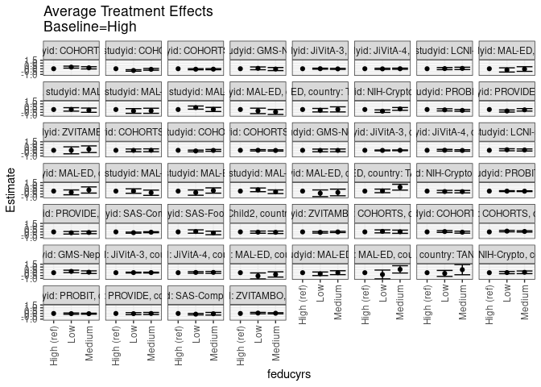

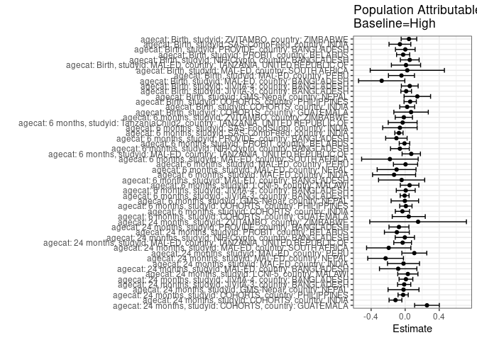

## Results Table

### Parameter: TSM

| agecat | studyid | country | intervention_level | baseline_level | estimate | ci_lower | ci_upper |
| --- | --- | --- | --- | --- | --- | --- | --- |
| Birth | COHORTS | GUATEMALA | High | NA | -1.1169254 | -1.3365486 | -0.8973022 |
| Birth | COHORTS | GUATEMALA | Low | NA | -1.0241134 | -1.1829967 | -0.8652301 |
| Birth | COHORTS | GUATEMALA | Medium | NA | -1.0890077 | -1.2783010 | -0.8997145 |
| Birth | COHORTS | INDIA | High | NA | -1.0257549 | -1.1339302 | -0.9175795 |
| Birth | COHORTS | INDIA | Low | NA | -0.9616108 | -1.0774462 | -0.8457754 |
| Birth | COHORTS | INDIA | Medium | NA | -1.0754607 | -1.2081435 | -0.9427779 |
| Birth | COHORTS | PHILIPPINES | High | NA | -0.7805773 | -0.8659202 | -0.6952343 |
| Birth | COHORTS | PHILIPPINES | Low | NA | -0.6442451 | -0.7436988 | -0.5447914 |
| Birth | COHORTS | PHILIPPINES | Medium | NA | -0.7013520 | -0.7893361 | -0.6133679 |
| Birth | GMS-Nepal | NEPAL | High | NA | -1.2589261 | -1.4345556 | -1.0832966 |
| Birth | GMS-Nepal | NEPAL | Low | NA | -1.0342802 | -1.1676783 | -0.9008822 |
| Birth | GMS-Nepal | NEPAL | Medium | NA | -1.1733258 | -1.3322543 | -1.0143973 |
| Birth | JiVitA-3 | BANGLADESH | High | NA | -0.7866314 | -0.8517852 | -0.7214776 |
| Birth | JiVitA-3 | BANGLADESH | Low | NA | -0.7706832 | -0.8046240 | -0.7367425 |
| Birth | JiVitA-3 | BANGLADESH | Medium | NA | -0.7690558 | -0.8016669 | -0.7364447 |
| Birth | JiVitA-4 | BANGLADESH | High | NA | -0.7370135 | -0.8428975 | -0.6311295 |
| Birth | JiVitA-4 | BANGLADESH | Low | NA | -0.6927322 | -0.7893734 | -0.5960910 |
| Birth | JiVitA-4 | BANGLADESH | Medium | NA | -0.6838475 | -0.8240170 | -0.5436779 |
| Birth | MAL-ED | BANGLADESH | High | NA | -0.6724345 | -0.9995845 | -0.3452845 |
| Birth | MAL-ED | BANGLADESH | Low | NA | -1.2481976 | -1.6628764 | -0.8335188 |
| Birth | MAL-ED | BANGLADESH | Medium | NA | -0.9811446 | -1.3036020 | -0.6586872 |
| Birth | MAL-ED | PERU | High | NA | 0.0290728 | -0.1499292 | 0.2080748 |
| Birth | MAL-ED | PERU | Low | NA | -0.1645548 | -0.4210652 | 0.0919556 |
| Birth | MAL-ED | PERU | Medium | NA | 0.0285818 | -0.2646479 | 0.3218115 |
| Birth | MAL-ED | SOUTH AFRICA | High | NA | 0.2810000 | -0.1017325 | 0.6637325 |
| Birth | MAL-ED | SOUTH AFRICA | Low | NA | -0.0364286 | -0.7135146 | 0.6406575 |
| Birth | MAL-ED | SOUTH AFRICA | Medium | NA | 0.8666667 | 0.3467047 | 1.3866286 |
| Birth | MAL-ED | TANZANIA, UNITED REPUBLIC OF | High | NA | 0.7446774 | 0.5287317 | 0.9606232 |
| Birth | MAL-ED | TANZANIA, UNITED REPUBLIC OF | Low | NA | 0.6161538 | 0.1324976 | 1.0998101 |
| Birth | MAL-ED | TANZANIA, UNITED REPUBLIC OF | Medium | NA | 1.2775000 | 0.4059642 | 2.1490358 |

[output cut: 126 more lines]

### Parameter: E(Y)

| agecat | studyid | country | intervention_level | baseline_level | estimate | ci_lower | ci_upper |
| --- | --- | --- | --- | --- | --- | --- | --- |
| Birth | COHORTS | GUATEMALA | NA | NA | -1.0475905 | -1.1510656 | -0.9441155 |
| Birth | COHORTS | INDIA | NA | NA | -1.0020759 | -1.0646599 | -0.9394920 |
| Birth | COHORTS | PHILIPPINES | NA | NA | -0.7218585 | -0.7694262 | -0.6742908 |
| Birth | GMS-Nepal | NEPAL | NA | NA | -1.1161562 | -1.2038617 | -1.0284508 |
| Birth | JiVitA-3 | BANGLADESH | NA | NA | -0.7747631 | -0.7940385 | -0.7554876 |
| Birth | JiVitA-4 | BANGLADESH | NA | NA | -0.6831985 | -0.7361386 | -0.6302583 |
| Birth | MAL-ED | BANGLADESH | NA | NA | -0.9483613 | -1.1437809 | -0.7529418 |
| Birth | MAL-ED | PERU | NA | NA | -0.0145789 | -0.1426994 | 0.1135416 |
| Birth | MAL-ED | SOUTH AFRICA | NA | NA | 0.3060606 | -0.0577506 | 0.6698718 |
| Birth | MAL-ED | TANZANIA, UNITED REPUBLIC OF | NA | NA | 0.7542708 | 0.5468640 | 0.9616776 |
| Birth | NIH-Crypto | BANGLADESH | NA | NA | -1.2441513 | -1.3281130 | -1.1601897 |
| Birth | PROBIT | BELARUS | NA | NA | -1.1437060 | -1.3543158 | -0.9330962 |
| Birth | PROVIDE | BANGLADESH | NA | NA | -1.2984586 | -1.3752758 | -1.2216415 |
| Birth | SAS-CompFeed | INDIA | NA | NA | -0.6685468 | -0.8459689 | -0.4911247 |
| Birth | ZVITAMBO | ZIMBABWE | NA | NA | -0.5092691 | -0.5354330 | -0.4831051 |
| 6 months | COHORTS | GUATEMALA | NA | NA | 0.1987403 | 0.1250477 | 0.2724329 |
| 6 months | COHORTS | INDIA | NA | NA | -0.6502599 | -0.7103477 | -0.5901722 |
| 6 months | COHORTS | PHILIPPINES | NA | NA | -0.2839930 | -0.3263706 | -0.2416154 |
| 6 months | GMS-Nepal | NEPAL | NA | NA | -0.6031912 | -0.6894381 | -0.5169444 |
| 6 months | JiVitA-3 | BANGLADESH | NA | NA | -0.5904964 | -0.6106039 | -0.5703890 |
| 6 months | JiVitA-4 | BANGLADESH | NA | NA | -0.3852207 | -0.4232704 | -0.3471709 |
| 6 months | LCNI-5 | MALAWI | NA | NA | 0.4414163 | 0.3697939 | 0.5130386 |
| 6 months | MAL-ED | BANGLADESH | NA | NA | -0.3007955 | -0.4778591 | -0.1237319 |
| 6 months | MAL-ED | INDIA | NA | NA | -0.7272766 | -0.9000901 | -0.5544630 |
| 6 months | MAL-ED | NEPAL | NA | NA | 0.0334035 | -0.1647857 | 0.2315927 |
| 6 months | MAL-ED | PERU | NA | NA | 1.0860565 | 0.9516698 | 1.2204433 |
| 6 months | MAL-ED | SOUTH AFRICA | NA | NA | 0.3834783 | 0.1440275 | 0.6229290 |
| 6 months | MAL-ED | TANZANIA, UNITED REPUBLIC OF | NA | NA | 0.5336484 | 0.3899788 | 0.6773181 |
| 6 months | NIH-Crypto | BANGLADESH | NA | NA | 0.0297622 | -0.0491685 | 0.1086930 |
| 6 months | PROBIT | BELARUS | NA | NA | 0.5730055 | 0.5136977 | 0.6323133 |
| 6 months | PROVIDE | BANGLADESH | NA | NA | -0.1990907 | -0.2817968 | -0.1163845 |
| 6 months | SAS-CompFeed | INDIA | NA | NA | -0.6641059 | -0.8040033 | -0.5242086 |
| 6 months | SAS-FoodSuppl | INDIA | NA | NA | -1.0121579 | -1.1280429 | -0.8962729 |
| 6 months | TanzaniaChild2 | TANZANIA, UNITED REPUBLIC OF | NA | NA | 0.0791782 | 0.0263777 | 0.1319787 |
| 6 months | ZVITAMBO | ZIMBABWE | NA | NA | 0.3153847 | 0.2894045 | 0.3413649 |
| 24 months | COHORTS | GUATEMALA | NA | NA | -0.2662176 | -0.3220630 | -0.2103721 |
| 24 months | COHORTS | INDIA | NA | NA | -0.6051533 | -0.6581071 | -0.5521995 |
| 24 months | COHORTS | PHILIPPINES | NA | NA | -0.6155714 | -0.6532287 | -0.5779140 |
| 24 months | GMS-Nepal | NEPAL | NA | NA | -1.1331550 | -1.2220936 | -1.0442165 |
| 24 months | JiVitA-3 | BANGLADESH | NA | NA | -1.2984354 | -1.3225016 | -1.2743692 |
| 24 months | JiVitA-4 | BANGLADESH | NA | NA | -1.2222794 | -1.2547188 | -1.1898401 |
| 24 months | LCNI-5 | MALAWI | NA | NA | -0.0443153 | -0.1269075 | 0.0382769 |
| 24 months | MAL-ED | BANGLADESH | NA | NA | -0.9042735 | -1.0737243 | -0.7348227 |
| 24 months | MAL-ED | INDIA | NA | NA | -0.9451515 | -1.0860650 | -0.8042380 |
| 24 months | MAL-ED | NEPAL | NA | NA | -0.4668132 | -0.6466833 | -0.2869431 |
| 24 months | MAL-ED | PERU | NA | NA | 0.1321189 | -0.0027984 | 0.2670362 |
| 24 months | MAL-ED | SOUTH AFRICA | NA | NA | 0.3583333 | 0.1644154 | 0.5522513 |
| 24 months | MAL-ED | TANZANIA, UNITED REPUBLIC OF | NA | NA | 0.1084840 | -0.0300100 | 0.2469780 |
| 24 months | NIH-Crypto | BANGLADESH | NA | NA | -0.6103502 | -0.7050157 | -0.5156847 |
| 24 months | PROBIT | BELARUS | NA | NA | 0.6953371 | 0.5818973 | 0.8087769 |
| 24 months | PROVIDE | BANGLADESH | NA | NA | -0.8928670 | -0.9755153 | -0.8102187 |
| 24 months | ZVITAMBO | ZIMBABWE | NA | NA | -1.1889512 | -1.2920613 | -1.0858411 |

### Parameter: ATE

| agecat | studyid | country | intervention_level | baseline_level | estimate | ci_lower | ci_upper |
| --- | --- | --- | --- | --- | --- | --- | --- |
| Birth | COHORTS | GUATEMALA | High | High | 0.0000000 | 0.0000000 | 0.0000000 |
| Birth | COHORTS | GUATEMALA | Low | High | 0.0928120 | -0.1697092 | 0.3553331 |
| Birth | COHORTS | GUATEMALA | Medium | High | 0.0279177 | -0.2543285 | 0.3101638 |
| Birth | COHORTS | INDIA | High | High | 0.0000000 | 0.0000000 | 0.0000000 |
| Birth | COHORTS | INDIA | Low | High | 0.0641441 | -0.0926411 | 0.2209292 |
| Birth | COHORTS | INDIA | Medium | High | -0.0497058 | -0.2194649 | 0.1200533 |
| Birth | COHORTS | PHILIPPINES | High | High | 0.0000000 | 0.0000000 | 0.0000000 |
| Birth | COHORTS | PHILIPPINES | Low | High | 0.1363321 | 0.0067630 | 0.2659013 |
| Birth | COHORTS | PHILIPPINES | Medium | High | 0.0792252 | -0.0415261 | 0.1999765 |
| Birth | GMS-Nepal | NEPAL | High | High | 0.0000000 | 0.0000000 | 0.0000000 |
| Birth | GMS-Nepal | NEPAL | Low | High | 0.2246459 | 0.0100096 | 0.4392821 |
| Birth | GMS-Nepal | NEPAL | Medium | High | 0.0856003 | -0.1458489 | 0.3170495 |
| Birth | JiVitA-3 | BANGLADESH | High | High | 0.0000000 | 0.0000000 | 0.0000000 |
| Birth | JiVitA-3 | BANGLADESH | Low | High | 0.0159482 | -0.0613966 | 0.0932929 |
| Birth | JiVitA-3 | BANGLADESH | Medium | High | 0.0175756 | -0.0544976 | 0.0896488 |
| Birth | JiVitA-4 | BANGLADESH | High | High | 0.0000000 | 0.0000000 | 0.0000000 |
| Birth | JiVitA-4 | BANGLADESH | Low | High | 0.0442813 | -0.0981348 | 0.1866973 |
| Birth | JiVitA-4 | BANGLADESH | Medium | High | 0.0531660 | -0.1193101 | 0.2256422 |
| Birth | MAL-ED | BANGLADESH | High | High | 0.0000000 | 0.0000000 | 0.0000000 |
| Birth | MAL-ED | BANGLADESH | Low | High | -0.5757631 | -1.1055130 | -0.0460131 |
| Birth | MAL-ED | BANGLADESH | Medium | High | -0.3087101 | -0.7717218 | 0.1543016 |
| Birth | MAL-ED | PERU | High | High | 0.0000000 | 0.0000000 | 0.0000000 |
| Birth | MAL-ED | PERU | Low | High | -0.1936276 | -0.5062395 | 0.1189843 |
| Birth | MAL-ED | PERU | Medium | High | -0.0004910 | -0.3442412 | 0.3432592 |
| Birth | MAL-ED | SOUTH AFRICA | High | High | 0.0000000 | 0.0000000 | 0.0000000 |
| Birth | MAL-ED | SOUTH AFRICA | Low | High | -0.3174286 | -1.0952008 | 0.4603437 |
| Birth | MAL-ED | SOUTH AFRICA | Medium | High | 0.5856667 | -0.0599684 | 1.2313017 |
| Birth | MAL-ED | TANZANIA, UNITED REPUBLIC OF | High | High | 0.0000000 | 0.0000000 | 0.0000000 |
| Birth | MAL-ED | TANZANIA, UNITED REPUBLIC OF | Low | High | -0.1285236 | -0.6581988 | 0.4011517 |
| Birth | MAL-ED | TANZANIA, UNITED REPUBLIC OF | Medium | High | 0.5328226 | -0.3650679 | 1.4307130 |

[output cut: 126 more lines]

### Parameter: PAR

| agecat | studyid | country | intervention_level | baseline_level | estimate | ci_lower | ci_upper |
| --- | --- | --- | --- | --- | --- | --- | --- |
| Birth | COHORTS | GUATEMALA | High | NA | 0.0693349 | -0.1329891 | 0.2716589 |
| Birth | COHORTS | INDIA | High | NA | 0.0236790 | -0.0637442 | 0.1111021 |
| Birth | COHORTS | PHILIPPINES | High | NA | 0.0587187 | -0.0136191 | 0.1310566 |
| Birth | GMS-Nepal | NEPAL | High | NA | 0.1427698 | -0.0128887 | 0.2984284 |
| Birth | JiVitA-3 | BANGLADESH | High | NA | 0.0118683 | -0.0503575 | 0.0740942 |
| Birth | JiVitA-4 | BANGLADESH | High | NA | 0.0538150 | -0.0446740 | 0.1523041 |
| Birth | MAL-ED | BANGLADESH | High | NA | -0.2759268 | -0.5476547 | -0.0041990 |
| Birth | MAL-ED | PERU | High | NA | -0.0436518 | -0.1964763 | 0.1091728 |
| Birth | MAL-ED | SOUTH AFRICA | High | NA | 0.0250606 | -0.4109032 | 0.4610244 |
| Birth | MAL-ED | TANZANIA, UNITED REPUBLIC OF | High | NA | 0.0095934 | -0.1619187 | 0.1811055 |
| Birth | NIH-Crypto | BANGLADESH | High | NA | 0.0535777 | -0.0568721 | 0.1640274 |
| Birth | PROBIT | BELARUS | High | NA | -0.0239969 | -0.1009089 | 0.0529151 |
| Birth | PROVIDE | BANGLADESH | High | NA | 0.0014733 | -0.1140149 | 0.1169615 |
| Birth | SAS-CompFeed | INDIA | High | NA | -0.0617256 | -0.1896305 | 0.0661793 |
| Birth | ZVITAMBO | ZIMBABWE | High | NA | 0.0442780 | -0.0472331 | 0.1357891 |
| 6 months | COHORTS | GUATEMALA | High | NA | 0.0419241 | -0.1520472 | 0.2358954 |
| 6 months | COHORTS | INDIA | High | NA | -0.0325009 | -0.1158308 | 0.0508291 |
| 6 months | COHORTS | PHILIPPINES | High | NA | 0.0081520 | -0.0642572 | 0.0805611 |
| 6 months | GMS-Nepal | NEPAL | High | NA | -0.0037984 | -0.1651955 | 0.1575986 |
| 6 months | JiVitA-3 | BANGLADESH | High | NA | -0.0063717 | -0.0587017 | 0.0459583 |
| 6 months | JiVitA-4 | BANGLADESH | High | NA | 0.0067852 | -0.1042819 | 0.1178523 |
| 6 months | LCNI-5 | MALAWI | High | NA | 0.0518034 | -0.0571834 | 0.1607903 |
| 6 months | MAL-ED | BANGLADESH | High | NA | -0.0415249 | -0.3126158 | 0.2295661 |
| 6 months | MAL-ED | INDIA | High | NA | -0.1302873 | -0.3831669 | 0.1225922 |
| 6 months | MAL-ED | NEPAL | High | NA | -0.1007657 | -0.3289666 | 0.1274352 |
| 6 months | MAL-ED | PERU | High | NA | 0.0041874 | -0.1380585 | 0.1464333 |
| 6 months | MAL-ED | SOUTH AFRICA | High | NA | -0.1794588 | -0.5115078 | 0.1525902 |
| 6 months | MAL-ED | TANZANIA, UNITED REPUBLIC OF | High | NA | 0.0716135 | -0.0360872 | 0.1793142 |
| 6 months | NIH-Crypto | BANGLADESH | High | NA | -0.0619242 | -0.1721987 | 0.0483502 |
| 6 months | PROBIT | BELARUS | High | NA | -0.0081975 | -0.0697440 | 0.0533490 |
| 6 months | PROVIDE | BANGLADESH | High | NA | -0.1030991 | -0.2290326 | 0.0228345 |
| 6 months | SAS-CompFeed | INDIA | High | NA | -0.0733844 | -0.1220361 | -0.0247327 |
| 6 months | SAS-FoodSuppl | INDIA | High | NA | -0.0618692 | -0.2641268 | 0.1403884 |
| 6 months | TanzaniaChild2 | TANZANIA, UNITED REPUBLIC OF | High | NA | -0.0295760 | -0.1991895 | 0.1400376 |
| 6 months | ZVITAMBO | ZIMBABWE | High | NA | -0.0157820 | -0.1169957 | 0.0854316 |
| 24 months | COHORTS | GUATEMALA | High | NA | 0.2560189 | 0.1108267 | 0.4012112 |
| 24 months | COHORTS | INDIA | High | NA | -0.1138803 | -0.1891429 | -0.0386176 |
| 24 months | COHORTS | PHILIPPINES | High | NA | -0.0239966 | -0.0838804 | 0.0358872 |
| 24 months | GMS-Nepal | NEPAL | High | NA | -0.0194959 | -0.2013410 | 0.1623491 |
| 24 months | JiVitA-3 | BANGLADESH | High | NA | -0.0116436 | -0.0891019 | 0.0658146 |
| 24 months | JiVitA-4 | BANGLADESH | High | NA | 0.0090919 | -0.0716671 | 0.0898509 |
| 24 months | LCNI-5 | MALAWI | High | NA | 0.0314004 | -0.0871231 | 0.1499239 |
| 24 months | MAL-ED | BANGLADESH | High | NA | -0.0822174 | -0.3019530 | 0.1375181 |
| 24 months | MAL-ED | INDIA | High | NA | -0.0197472 | -0.2077494 | 0.1682549 |
| 24 months | MAL-ED | NEPAL | High | NA | -0.2300191 | -0.4399007 | -0.0201376 |
| 24 months | MAL-ED | PERU | High | NA | 0.1074438 | -0.0391206 | 0.2540081 |
| 24 months | MAL-ED | SOUTH AFRICA | High | NA | -0.1931946 | -0.4532613 | 0.0668721 |
| 24 months | MAL-ED | TANZANIA, UNITED REPUBLIC OF | High | NA | -0.0298445 | -0.1337922 | 0.0741032 |
| 24 months | NIH-Crypto | BANGLADESH | High | NA | -0.0039206 | -0.1169603 | 0.1091190 |
| 24 months | PROBIT | BELARUS | High | NA | -0.0978173 | -0.2439410 | 0.0483064 |
| 24 months | PROVIDE | BANGLADESH | High | NA | -0.0730491 | -0.1900593 | 0.0439611 |
| 24 months | ZVITAMBO | ZIMBABWE | High | NA | 0.1517614 | -0.4160019 | 0.7195248 |